It was mentioned that GAMs are generally fit using a backfitting approach. The idea behind backfitting is actually quite simple. We will now explore backfitting in the context of linear additive model. Download the data from

```r
library(tidyverse)
income <- read_csv("http://www-bcf.usc.edu/~gareth/ISL/Income2.csv")
```

Suppose we have the model
$$y_i=\beta_0 + f_1(x_{i1}) + f_2(x_{i2}) + \varepsilon.$$
where $y_i$ is `Income`, $x_{i1}$ is `Education` and $x_{i2}=$ `Seniority`.

1. Suppose $f_1$ and $f_2$ are linear. Fit a multiple linear regression model to the data. Denote the estimate of $f_1$ as $\hat f_1$. (You should center the function $\hat f_1$)

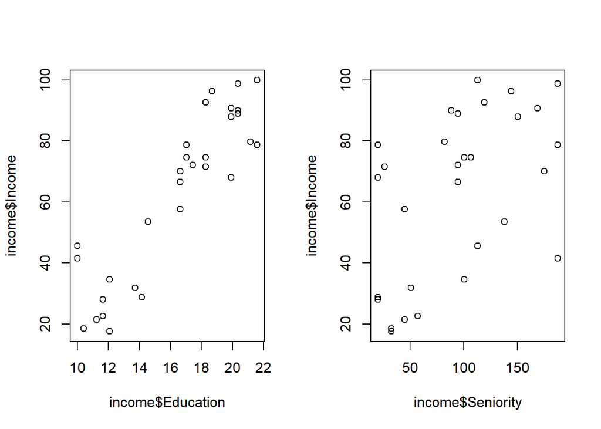

```r
par(mfrow =c(1,2))
plot(income$Income~income$Education)
plot(income$Income~income$Seniority)
```

```r
#Income~Education+Seniority
# pg301
y<-income$Income
x1<-income$Education
x2<-income$Seniority

f1<-0.75
f2<-0.25

a<-y-f1*x1
f2_hat<-lm(a~x2)$coef
f2_hat
```

```
## (Intercept)          x2
##  27.8052026   0.2413102
```

```r
a<-y-f2*x2
f1_hat<-lm(a~x1)$coef
f1_hat
```

```
## (Intercept)          x1
##  -53.731434    5.676155
```

2. Compute the partial residual $z_{1i} = y_i - \hat f_1(x_{1i})$ and plot $z_{1i}$ vs $x_{2i}$. Then fit a smoothing spline on the scatter plot. Denote the centered estimated smooth function as $\hat f_2$.

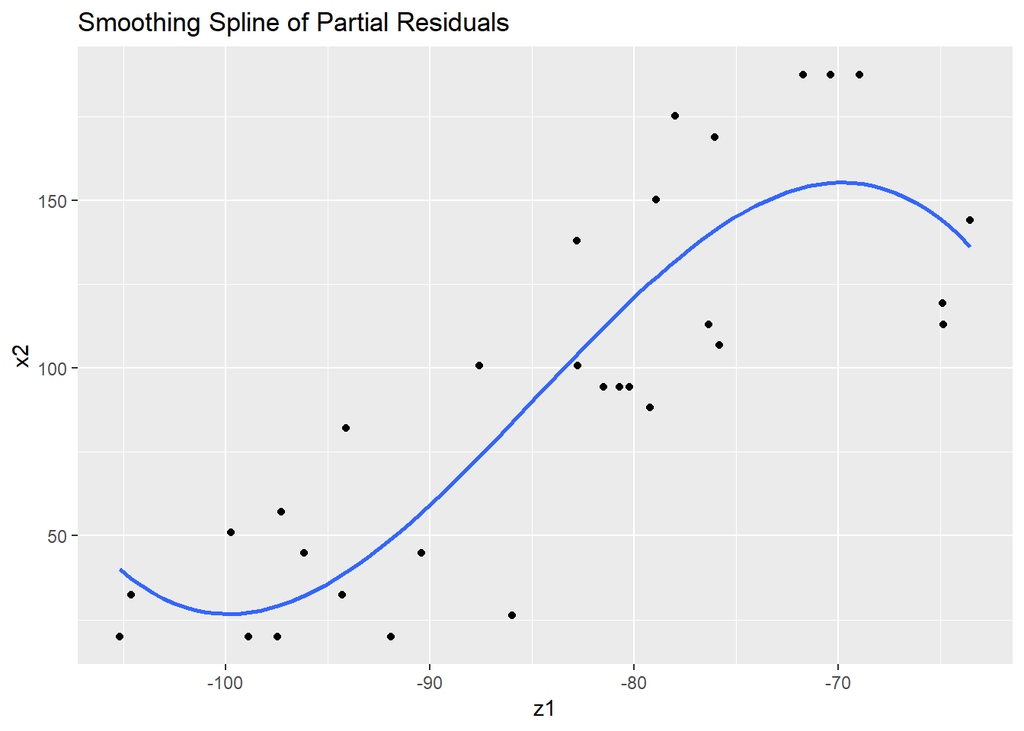

```r
z1<-y-f1_hat[2]*x1+f1_hat[1]

prz1<-data.frame(cbind(z1,x2))

ggplot(prz1,aes(z1, x2)) +
  geom_point() +
  ggtitle("Smoothing Spline of Partial Residuals") +
  geom_smooth(method="lm", formula = y ~ splines::bs(x), se = FALSE)
```

3. Compute the partial residual $z_{2i} = y_i - \hat f_2(x_{2i})$ and plot $z_{2i}$ vs $x_{1i}$. Then fit a smoothing spline on the scatter plot. Denote the centered estimated smooth function as $\hat f_1$.

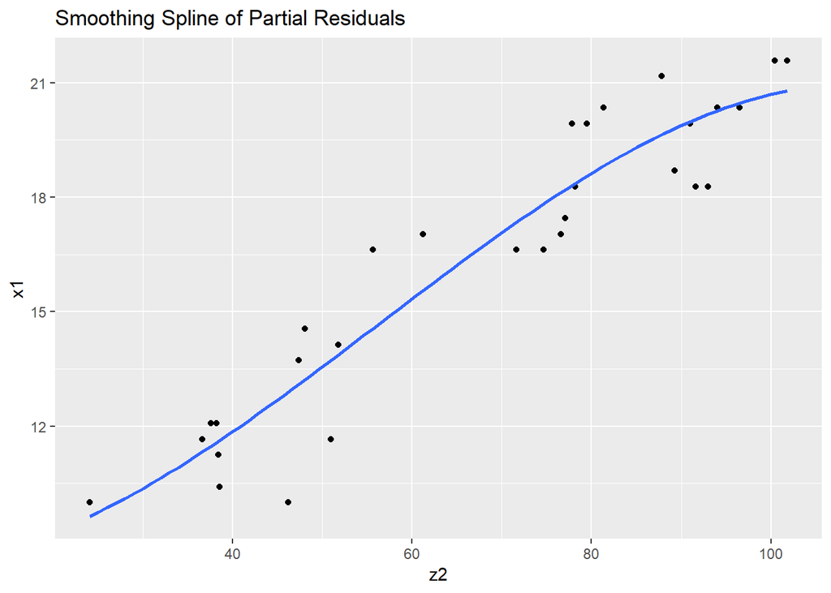

```r
z2<-y-f2_hat[2]*x2++f2_hat[1]

prz1<-data.frame(cbind(z2,x1))

ggplot(prz1,aes(z2, x1)) +
  geom_point() +
  ggtitle("Smoothing Spline of Partial Residuals") +
  geom_smooth(method="lm", formula = y ~ splines::bs(x), se = FALSE)
```

4. Repeat (b) and (c) a number of times until convergence. (One way to declare convergence is to look at the changes of $\hat f_1(x_{1})+\hat f_2(x_2)$ in successive iterations.)

```r
#y<-income$Income
#x1<-income$Education
#x2<-income$Seniority
#f1<-1
#f2<-1

model_results <- data.frame(0.0, 0.0, 0.0)
names(model_results) <- c('beta0', 'f1', 'f2')
for (i in 1:25) {
  f1 <- model_results[nrow(model_results), 2]
  a <- income$Income - f1 * income$Education
  f2 <- lm(a ~ income$Seniority)$coef[2]
  a <- income$Income - f2 * income$Seniority
  f1 <- lm(a ~ income$Education)$coef[2]
  beta0 <- lm(a ~ income$Education)$coef[1]

  print(paste(i," - beta0=",beta0,", f1=",f1,", f2=",f2,sep=""))

  model_results[nrow(model_results) + 1,] <- list(beta0, f1, f2)
}
```

```
## [1] "1 - beta0=-53.7923021182603, f1=5.67249202761439, f2=0.251287952327656"
## [1] "2 - beta0=-50.2258838673066, f1=5.88711612615261, f2=0.175823036492601"
## [1] "3 - beta0=-50.0909450611532, f1=5.89523663182262, f2=0.172967750058788"
## [1] "4 - beta0=-50.0858395238536, f1=5.89554387883163, f2=0.172859717597228"
## [1] "5 - beta0=-50.0856463510232, f1=5.89555550381268, f2=0.172855630086913"
## [1] "6 - beta0=-50.0856390421466, f1=5.89555594365483, f2=0.172855475432096"
## [1] "7 - beta0=-50.0856387656083, f1=5.89555596029667, f2=0.172855469580584"
## [1] "8 - beta0=-50.0856387551452, f1=5.89555596092633, f2=0.172855469359187"
## [1] "9 - beta0=-50.0856387547494, f1=5.89555596095016, f2=0.17285546935081"
## [1] "10 - beta0=-50.0856387547343, f1=5.89555596095106, f2=0.172855469350493"
## [1] "11 - beta0=-50.0856387547338, f1=5.89555596095109, f2=0.172855469350481"
## [1] "12 - beta0=-50.0856387547338, f1=5.89555596095109, f2=0.172855469350481"
## [1] "13 - beta0=-50.0856387547338, f1=5.89555596095109, f2=0.172855469350481"
## [1] "14 - beta0=-50.0856387547338, f1=5.89555596095109, f2=0.172855469350481"
## [1] "15 - beta0=-50.0856387547338, f1=5.89555596095109, f2=0.172855469350481"
## [1] "16 - beta0=-50.0856387547338, f1=5.89555596095109, f2=0.172855469350481"
## [1] "17 - beta0=-50.0856387547338, f1=5.89555596095109, f2=0.172855469350481"
## [1] "18 - beta0=-50.0856387547338, f1=5.89555596095109, f2=0.172855469350481"
## [1] "19 - beta0=-50.0856387547338, f1=5.89555596095109, f2=0.172855469350481"
## [1] "20 - beta0=-50.0856387547338, f1=5.89555596095109, f2=0.172855469350481"
## [1] "21 - beta0=-50.0856387547338, f1=5.89555596095109, f2=0.172855469350481"
## [1] "22 - beta0=-50.0856387547338, f1=5.89555596095109, f2=0.172855469350481"
## [1] "23 - beta0=-50.0856387547338, f1=5.89555596095109, f2=0.172855469350481"
## [1] "24 - beta0=-50.0856387547338, f1=5.89555596095109, f2=0.172855469350481"
## [1] "25 - beta0=-50.0856387547338, f1=5.89555596095109, f2=0.172855469350481"
```

5. On this data set, how many backfitting iterations were required in order to obtain a good result? Plot the function $\hat f_1(x_{1})+\hat f_2(x_2)$ over the a grid of $X_1$ and $X_2$.

This dataset only required 11 backfitting iterations to obtain a good result.

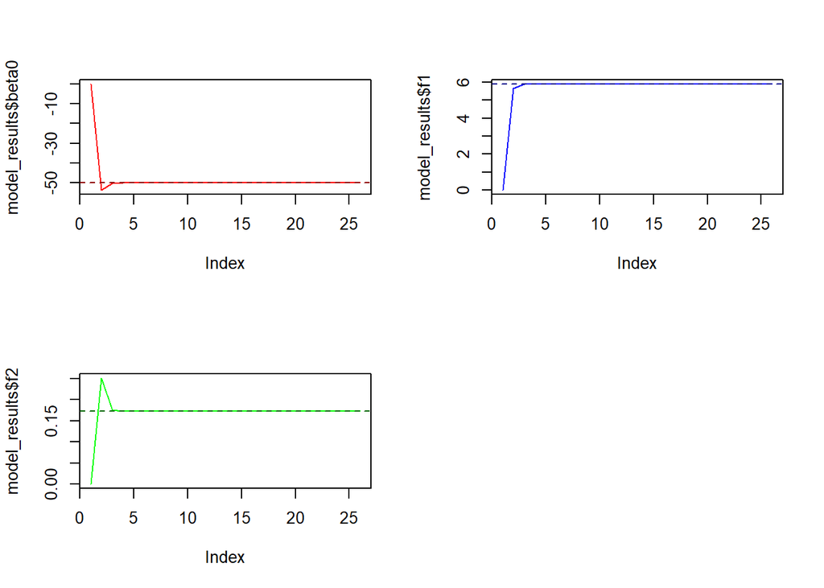

```r
#y<-income$Income
#x1<-income$Education
#x2<-income$Seniority

lm_coef <- coef(lm(income$Income ~ income$Education + income$Seniority))

par(mfrow =c(2,2))
plot(model_results$beta0, col = 'red', type = 'l')
abline(h = lm_coef[1], col = 'darkred', lty = 2)

plot(model_results$f1, col = 'blue', type = 'l')
abline(h = lm_coef[2], col = 'darkblue', lty = 2)

plot(model_results$f2, col = 'green', type= 'l')
abline(h = lm_coef[3], col = 'darkgreen', lty = 2)
```